# Modeling New Zealand eel populations the VAST stream network spatial model

## Installing and loading VAST

```r
devtools::install_github("merrillrudd/VAST")
```

## Data

Load the New Zealand longfin eel data file made available through VAST:

```r
library(VAST)
data(NZ_longfin_eel, package="FishStatsUtils")
```

### Explore stream network data

There are 10539 observations in the dataset across 41 years and 8038 segments.

For use in VAST, each segment is defined by a downstream parent node and an upstream child node, along with the distance between parent and child nodes and the latitude and longitude of each node.

We used the heading `nz_tnode` as the parent node and `nz_fnode` as the child node to define each segment in the New Zealand dataset including presence/absence of longfin eels.

```r
## parent nodes - downstream
parents <- NZ_longfin_eel$nz_tnode

## child nodes - upstream
children <- NZ_longfin_eel$nz_fnode

## unique nodes
pnodes <- unique(parents) ## 7486 downstream parent nodes
cnodes <- unique(children) ## 8038 upstream child nodes
nodes <- unique(c(pnodes, cnodes)) ## 14338 unique nodes

## headwater nodes
hcnodes <- unique(NZ_longfin_eel$nz_fnode[which(NZ_longfin_eel$Headwater==1)])

## coastal nodes
rpnodes <- unique(NZ_longfin_eel$nz_tnode[which(NZ_longfin_eel$NextDownSeg==0)])
```

There are 14338 unique nodes within the dataset, with 8038 unique upstream child nodes and 7486 unique downstream parent nodes.

17% of upstream child nodes are headwater nodes, and 5% of downstream parent nodes connect to the sea. 1% of segments have a headwater upstream child node and parent node connecting to the sea, thus disconnected from other stream segments.

However, only 16% of parent nodes are also child nodes. 5% of downstream parent nodes are along the coast, leaving 79% of downstream parent nodes disconnected inland.

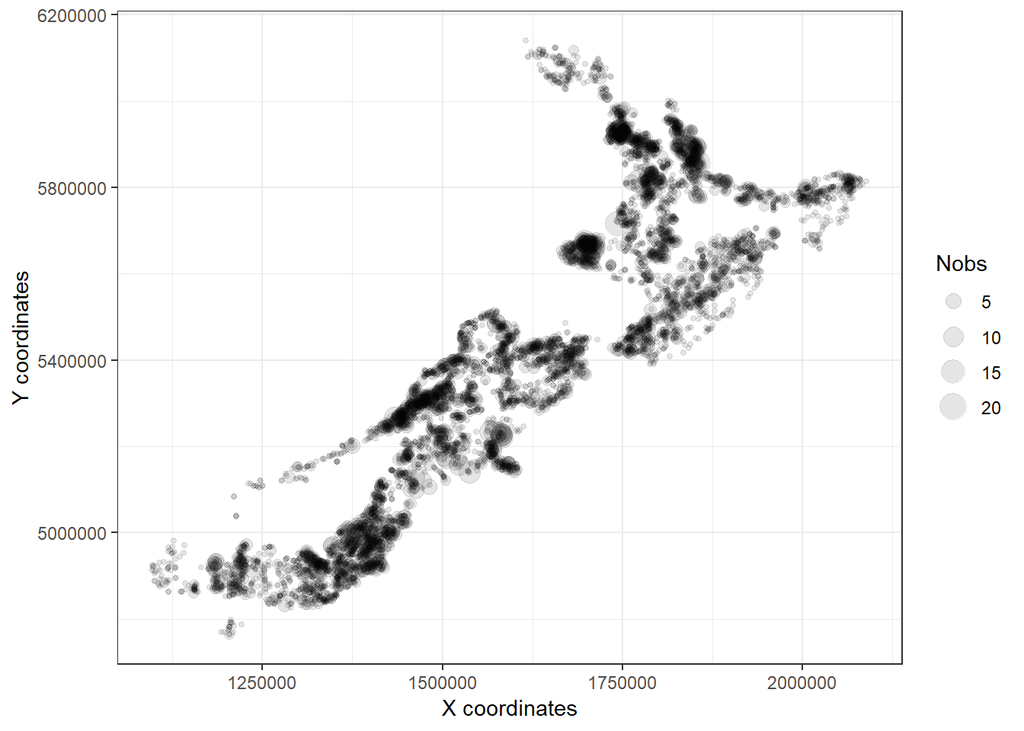

Downstream nodes of stream segments sampled across years, where `Nobs` is the number of years where each segment is sampled.

### Format data for VAST

First, VAST uses the node number as a pointer in a network grid that is defined by the number of nodes, and therefore the nodes must be re-cast to an index from 1 to length(unique(nodes)) instead of their raw node names (e.g. 12345, 305634). Therefore, we assigned each node to a number from 1 to length(unique(nodes)):

```r
## change nodes (xxxx - xxxxx) to indexed nodes (1-length(nodes))
inodes <- seq_along(nodes)
ipnodes <- sapply(1:length(pnodes),function(x) inodes[which(nodes == pnodes[x])]) ## parents
icnodes <- sapply(1:length(cnodes),function(x) inodes[which(nodes == cnodes[x])]) ## children

## replace parent and child nodes with indexed nodes
parent_i <- sapply(1:nrow(NZ_longfin_eel), function(x){
    ipnodes[which(pnodes == NZ_longfin_eel$nz_tnode[x])]
})
child_i <- sapply(1:nrow(NZ_longfin_eel), function(x){
    icnodes[which(cnodes == NZ_longfin_eel$nz_fnode[x])]
})

## rename each obseveration to indexed nodes
NZ_longfin_eel$parent_i <- parent_i
NZ_longfin_eel$child_i <- child_i
```